# R Notebook

Big mart sales prediction problem:

```r
install.packages("corrplot")
install.packages("xgboost")
```

[output not shown]

```
  Binaries will be installed
```

```r
install.packages("cowplot")
library(data.table) # used for reading and manipulation of data
library(dplyr)      # used for data manipulation and joining
library(ggplot2)    # used for ploting
library(caret)      # used for modeling
library(corrplot)   # used for making correlation plot
library(xgboost)    # used for building XGBoost model
library(cowplot)    # used for combining multiple plots
train = fread("Train_UWu5bXk.csv")
test = fread("Test_u94Q5KV.csv")
submission = fread("SampleSubmission_TmnO39y.csv")
dim(train);dim(test)
```

```
[1] 8523   12
[1] 5681   11
```

Combine train and test features to combinely understand the data distributions

```r
test[,Item_Outlet_Sales := NA]
combi = rbind(train, test) # combining train and test datasets
dim(combi)
```

```
[1] 14204    12
```

Visualizing the continuous target variable in a histogram

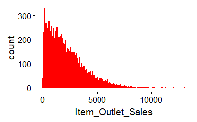

```r
ggplot(train) + geom_histogram(aes(train$Item_Outlet_Sales), binwidth = 100, fill = "red") +
  xlab("Item_Outlet_Sales")
```

Independent Variables (numeric variables)

```
Removed 2439 rows
containing non-finite
values (stat_bin).
```

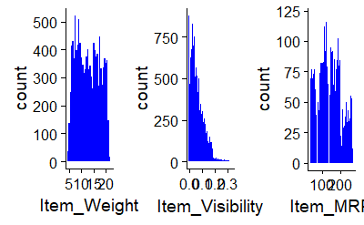

```r
p1 = ggplot(combi) + geom_histogram(aes(Item_Weight), binwidth = 0.5, fill = "blue")
p2 = ggplot(combi) + geom_histogram(aes(Item_Visibility), binwidth = 0.005, fill = "blue")
p3 = ggplot(combi) + geom_histogram(aes(Item_MRP), binwidth = 1, fill = "blue")
plot_grid(p1, p2, p3, nrow = 1) # plot_grid() from cowplot package
```

Observations

There seems to be no clear-cut pattern in Item_Weight. Item_Visibility is right-skewed and should be transformed to curb its skewness. We can clearly see 4 different distributions for Item_MRP. It is an interesting insight.

Independent Variables (categorical variables)

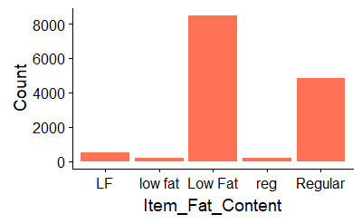

```r
ggplot(combi %>% group_by(Item_Fat_Content) %>% summarise(Count = n())) +
  geom_bar(aes(Item_Fat_Content, Count), stat = "identity", fill = "coral1")
```

```r
combi$Item_Fat_Content[combi$Item_Fat_Content == "LF"] = "Low Fat"
combi$Item_Fat_Content[combi$Item_Fat_Content == "low fat"] = "Low Fat"
combi$Item_Fat_Content[combi$Item_Fat_Content == "reg"] = "Regular"
```

As can be observed, “Low Fat”, “low fat”, “LF” can all be classified as “Low Fat” and similar with “Regular”

[figure not shown]

```r
# plot for Item_Type
p4 = ggplot(combi %>% group_by(Item_Type) %>% summarise(Count = n())) +
  geom_bar(aes(Item_Type, Count), stat = "identity", fill = "coral1") +
  xlab("") +
  geom_label(aes(Item_Type, Count, label = Count), vjust = 0.5) +
  theme(axis.text.x = element_text(angle = 45, hjust = 1))+
  ggtitle("Item_Type")
# plot for Outlet_Identifier
p5 = ggplot(combi %>% group_by(Outlet_Identifier) %>% summarise(Count = n())) +
  geom_bar(aes(Outlet_Identifier, Count), stat = "identity", fill = "coral1") +
  geom_label(aes(Outlet_Identifier, Count, label = Count), vjust = 0.5) +
  theme(axis.text.x = element_text(angle = 45, hjust = 1))
# plot for Outlet_Size
p6 = ggplot(combi %>% group_by(Outlet_Size) %>% summarise(Count = n())) +
  geom_bar(aes(Outlet_Size, Count), stat = "identity", fill = "coral1") +
  geom_label(aes(Outlet_Size, Count, label = Count), vjust = 0.5) +
  theme(axis.text.x = element_text(angle = 45, hjust = 1))
second_row = plot_grid(p5, p6, nrow = 1)
plot_grid(p4, second_row, ncol = 1)
```

As can be observed in “Outlet_Size”, a major part of 4016 observations have no defined label. These could be missing values.

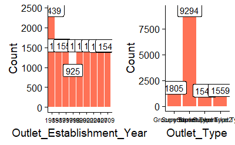

```r
# plot for Outlet_Establishment_Year
p7 = ggplot(combi %>% group_by(Outlet_Establishment_Year) %>% summarise(Count = n())) +
  geom_bar(aes(factor(Outlet_Establishment_Year), Count), stat = "identity", fill = "coral1") +
  geom_label(aes(factor(Outlet_Establishment_Year), Count, label = Count), vjust = 0.5) +
  xlab("Outlet_Establishment_Year") +
  theme(axis.text.x = element_text(size = 8.5))
# plot for Outlet_Type
p8 = ggplot(combi %>% group_by(Outlet_Type) %>% summarise(Count = n())) +
  geom_bar(aes(Outlet_Type, Count), stat = "identity", fill = "coral1") +
  geom_label(aes(factor(Outlet_Type), Count, label = Count), vjust = 0.5) +
  theme(axis.text.x = element_text(size = 8.5))
# ploting both plots together
plot_grid(p7, p8, ncol = 2)
```

Observations

Lesser number of observations in 1998 Supermarket Type 1 seems to be the most popular category of Outlet_Type.

bivariate analysis : plot all independent variables with respect to the target variable

```
Removed 1463 rows
containing missing values
(geom_point).
```

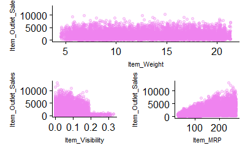

```r
train = combi[1:nrow(train)]
# Item_Weight vs Item_Outlet_Sales
p9 = ggplot(train) +
     geom_point(aes(Item_Weight, Item_Outlet_Sales), colour = "violet", alpha = 0.3) +
     theme(axis.title = element_text(size = 8.5))
# Item_Visibility vs Item_Outlet_Sales
p10 = ggplot(train) +
      geom_point(aes(Item_Visibility, Item_Outlet_Sales), colour = "violet", alpha = 0.3) +
      theme(axis.title = element_text(size = 8.5))
# Item_MRP vs Item_Outlet_Sales
p11 = ggplot(train) +
      geom_point(aes(Item_MRP, Item_Outlet_Sales), colour = "violet", alpha = 0.3) +
      theme(axis.title = element_text(size = 8.5))
second_row_2 = plot_grid(p10, p11, ncol = 2)
plot_grid(p9, second_row_2, nrow = 2)
```

Observations

Item_Outlet_Sales is spread well across the entire range -No obvious pattern. In Item_Visibility vs Item_Outlet_Sales, there is a string of points at Item_Visibility = 0.0 but, cannot be completely zero. We will take note of this issue and deal with it in the later stages. In the third plot of Item_MRP vs Item_Outlet_Sales, we can clearly see 4 segments of prices that can be used in feature engineering to create a new variable.

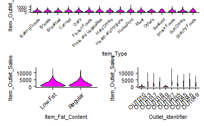

```r
# Item_Type vs Item_Outlet_Sales
p12 = ggplot(train) +
      geom_violin(aes(Item_Type, Item_Outlet_Sales), fill = "magenta") +
      theme(axis.text.x = element_text(angle = 45, hjust = 1),
            axis.text = element_text(size = 6),
            axis.title = element_text(size = 8.5))
# Item_Fat_Content vs Item_Outlet_Sales
p13 = ggplot(train) +
      geom_violin(aes(Item_Fat_Content, Item_Outlet_Sales), fill = "magenta") +
      theme(axis.text.x = element_text(angle = 45, hjust = 1),
            axis.text = element_text(size = 8),
            axis.title = element_text(size = 8.5))
# Outlet_Identifier vs Item_Outlet_Sales
p14 = ggplot(train) +
      geom_violin(aes(Outlet_Identifier, Item_Outlet_Sales), fill = "magenta") +
      theme(axis.text.x = element_text(angle = 45, hjust = 1),
            axis.text = element_text(size = 8),
            axis.title = element_text(size = 8.5))
second_row_3 = plot_grid(p13, p14, ncol = 2)
plot_grid(p12, second_row_3, ncol = 1)
```

Observations

Distribution of Item_Outlet_Sales across the categories of Item_Type is not very distinct and same is the case with Item_Fat_Content. The distribution for OUT010 and OUT019 categories of Outlet_Identifier are quite similar and very much different from the rest of the categories of Outlet_Identifier.

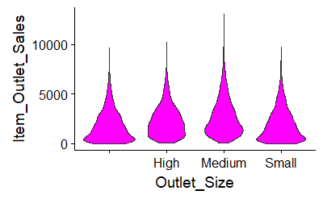

```r
ggplot(train) + geom_violin(aes(Outlet_Size, Item_Outlet_Sales), fill = "magenta")
```

As we can see, the first unnamed dataset looks similar to “Small” So, can replace those missing values with “Small” Other Independent variables -

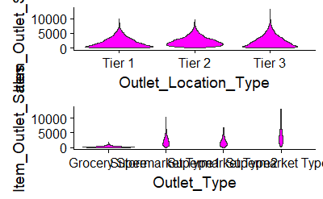

```r
p15 = ggplot(train) + geom_violin(aes(Outlet_Location_Type, Item_Outlet_Sales), fill = "magenta")
p16 = ggplot(train) + geom_violin(aes(Outlet_Type, Item_Outlet_Sales), fill = "magenta")
plot_grid(p15, p16, ncol = 1)
```

Observations

Tier 1 and Tier 3 locations of Outlet_Location_Type look similar. In the Outlet_Type plot, Grocery Store has most of its data points around the lower sales values as compared to the other categories.

Now, to handle missing values– 1. ItemWeights 2. Itemvisibility - zero error

```r
sum(is.na(combi$Item_Weight))
```

```
[1] 2439
```

```r
missing_index = which(is.na(combi$Item_Weight))
for(i in missing_index){

  item = combi$Item_Identifier[i]
  combi$Item_Weight[i] = mean(combi$Item_Weight[combi$Item_Identifier == item], na.rm = T)
}
sum(is.na(combi$Item_Weight))
```

```
[1] 0
```

```r
zero_index = which(combi$Item_Visibility == 0)
for(i in zero_index){

  item = combi$Item_Identifier[i]
  combi$Item_Visibility[i] = mean(combi$Item_Visibility[combi$Item_Identifier == item], na.rm = T)

}
```

```r
perishable = c("Breads", "Breakfast", "Dairy", "Fruits and Vegetables", "Meat", "Seafood")
non_perishable = c("Baking Goods", "Canned", "Frozen Foods", "Hard Drinks", "Health and Hygiene", "Household", "Soft Drinks")
# create a new feature 'Item_Type_new'
combi[,Item_Type_new := ifelse(Item_Type %in% perishable, "perishable", ifelse(Item_Type %in% non_perishable, "non_perishable", "not_sure"))]
```

Now, we can make sense of the item identifier feature by

```r
table(combi$Item_Type, substr(combi$Item_Identifier, 1, 2))
```

```
                          DR
  Baking Goods             0
  Breads                   0
  Breakfast                0
  Canned                   0
  Dairy                  229
  Frozen Foods             0
  Fruits and Vegetables    0
  Hard Drinks            362
  Health and Hygiene       0
  Household                0
  Meat                     0
  Others                   0
  Seafood                  0
  Snack Foods              0
  Soft Drinks            726
  Starchy Foods            0

                          FD
  Baking Goods          1086
  Breads                 416
  Breakfast              186
  Canned                1084
  Dairy                  907
  Frozen Foods          1426
  Fruits and Vegetables 2013
  Hard Drinks              0
  Health and Hygiene       0
  Household                0
  Meat                   736
  Others                   0
  Seafood                 89
  Snack Foods           1989
  Soft Drinks              0
  Starchy Foods          269

                          NC
  Baking Goods             0
  Breads                   0
  Breakfast                0
  Canned                   0
  Dairy                    0
  Frozen Foods             0
  Fruits and Vegetables    0
  Hard Drinks              0
  Health and Hygiene     858
  Household             1548
  Meat                     0
  Others                 280
  Seafood                  0
  Snack Foods              0
  Soft Drinks              0
  Starchy Foods            0
```

```r
combi[,Item_category := substr(combi$Item_Identifier, 1, 2)]
combi$Item_Fat_Content[combi$Item_category == "NC"] = "Non-Edible"
# years of operation for outlets
combi[,Outlet_Years := 2013 - Outlet_Establishment_Year]
combi$Outlet_Establishment_Year = as.factor(combi$Outlet_Establishment_Year)
# Price per unit weight
combi[,price_per_unit_wt := Item_MRP/Item_Weight]
# creating new independent variable - Item_MRP_clusters
combi[,Item_MRP_clusters := ifelse(Item_MRP < 69, "1st",
                                   ifelse(Item_MRP >= 69 & Item_MRP < 136, "2nd",
                                          ifelse(Item_MRP >= 136 & Item_MRP < 203, "3rd", "4th")))]
combi[,Outlet_Size_num := ifelse(Outlet_Size == "Small", 0,
                                 ifelse(Outlet_Size == "Medium", 1, 2))]
combi[,Outlet_Location_Type_num := ifelse(Outlet_Location_Type == "Tier 3", 0,
                                          ifelse(Outlet_Location_Type == "Tier 2", 1, 2))]
# removing categorical variables after label encoding
combi[, c("Outlet_Size", "Outlet_Location_Type") := NULL]
```

```r
ohe = dummyVars("~.", data = combi[,-c("Item_Identifier", "Outlet_Establishment_Year", "Item_Type")], fullRank = T)
ohe_df = data.table(predict(ohe, combi[,-c("Item_Identifier", "Outlet_Establishment_Year", "Item_Type")]))
combi = cbind(combi[,"Item_Identifier"], ohe_df)
```

```r
combi[,Item_Visibility := log(Item_Visibility + 1)] # log + 1 to avoid division by zero
combi[,price_per_unit_wt := log(price_per_unit_wt + 1)]
```

Scaling the variables

```r
num_vars = which(sapply(combi, is.numeric)) # index of numeric features
num_vars_names = names(num_vars)
combi_numeric = combi[,setdiff(num_vars_names, "Item_Outlet_Sales"), with = F]
prep_num = preProcess(combi_numeric, method=c("center", "scale"))
combi_numeric_norm = predict(prep_num, combi_numeric)
combi[,setdiff(num_vars_names, "Item_Outlet_Sales") := NULL] # removing numeric independent variables
combi = cbind(combi, combi_numeric_norm)
train = combi[1:nrow(train)]
test = combi[(nrow(train) + 1):nrow(combi)]
test[,Item_Outlet_Sales := NULL]
```

Examining Correlations among variables

```r
train
```

[output not shown]

[output cut: 990 more lines]

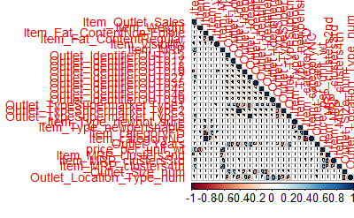

```r
cor_train = cor(train[,-c("Item_Identifier")])
corrplot(cor_train, method = "pie", type = "lower", tl.cex = 0.9)
```

Variables price_per_unit_wt and Item_Weight are highly correlated as the former one was created from the latter. Similarly price_per_unit_wt and Item_MRP are highly correlated for the same reason.

Linear Regression Model

```r
linear_reg_mod = lm(Item_Outlet_Sales ~ ., data = train[,-c("Item_Identifier")])
plot(linear_reg_mod)
submission$Item_Outlet_Sales = predict(linear_reg_mod, test[,-c("Item_Identifier")])
write.csv(submission, "Linear_Reg_submit.csv", row.names = F)
```

[output not shown]

To understand regression analysis, we can check the following assumptions

Normal-QQ plot - checking if the dataset has an underlying normal distribution.If the errors are not normally distributed, non - linear transformation of the variables (response or predictors) can bring improvement in the model.

Scale Location Plot - This helps in detecting variance among errors. It also shows the presence of outliers and how they are affecting the model. If this plot shows any pattern, it implies non-normal distribution of errors.

Residuals vs Leverage plot - also known as cooks distance plot, tends to show influential points vs others.

Ridge and Lasso regression are kinds of regularized regressions, while in ridge we used the squares of theta while in lasso we used absolute value of theta. Elasticnet regression has a combined network of both these methods.

RandomForest

Tuning can be done in 2 ways to tune some possible machine learning parameters 1. Tune Using Caret

Only mtry can be tuned This can be done by randomly searching values in a given range and choosing values in a range based on the accuracies attained

Other way is to generate accuracies on a grid of parameters which can be used to tune the parameters.

```r
set.seed(1237)
my_control = trainControl(method="cv", number=5) # 5-fold CV
tgrid = expand.grid(
  .mtry = c(3:10),
  .splitrule = "variance",
  .min.node.size = c(10,15,20)
)
rf_mod = train(x = train[, -c("Item_Identifier", "Item_Outlet_Sales")],
               y = train$Item_Outlet_Sales,
               method='ranger',
               trControl= my_control,
               tuneGrid = tgrid,
               num.trees = 400,
               importance = "permutation")
plot(rf_mod)
```

[output not shown]

2. Tune Using Algorithm Tools

tunerf - can be used to find the best optimal value for mtry given the dataset

Feature Importance can also be determined by plotting

```r
xgb_model = xgb.train(data = dtrain, params = param_list, nrounds = 430)
var_imp = xgb.importance(feature_names = setdiff(names(train), c("Item_Identifier", "Item_Outlet_Sales")),
                         model = xgb_model)
xgb.plot.importance(var_imp)
```

[output not shown]